# SHC 798 Assignment 2, 2025

Richard Lubega

2025-10-03

# SHC 798 Assignment 2, 2025

## Multiple Linear Analysis (MLR)

### Question 1: Concrete Strength

```r
pacman::p_load(tidymodels)

# Getting started with the dataset in concrete.csv
concrete <- read.csv(file.choose(), header = TRUE, na.strings = c("NA")) # open dataset
head(concrete) # View first few rows of the dataset
```

```
##   cement  wcr age strength
## 1  369.9 0.48  14     12.7
## 2  344.5 0.49  28     12.7
## 3  375.9 0.44  14     14.7
## 4  410.9 0.44  28     25.0
## 5  340.6 0.54  28      7.9
## 6  340.6 0.57  28      4.9
```

```r
summary(concrete) # Get an overview of the dataset
```

```
##      cement           wcr              age           strength
##  Min.   :271.6   Min.   :0.3700   Min.   : 7.00   Min.   :-0.700
##  1st Qu.:322.5   1st Qu.:0.4775   1st Qu.:14.00   1st Qu.: 5.950
##  Median :340.8   Median :0.5000   Median :28.00   Median : 8.800
##  Mean   :343.8   Mean   :0.4997   Mean   :21.47   Mean   : 9.485
##  3rd Qu.:366.2   3rd Qu.:0.5200   3rd Qu.:28.00   3rd Qu.:11.900
##  Max.   :424.1   Max.   :0.6200   Max.   :56.00   Max.   :25.000
```

```r
str(concrete) # inspect the dataset and viewing column data types
```

```
## 'data.frame':    60 obs. of  4 variables:
##  $ cement  : num  370 344 376 411 341 ...
##  $ wcr     : num  0.48 0.49 0.44 0.44 0.54 0.57 0.5 0.55 0.52 0.47 ...
##  $ age     : int  14 28 14 28 28 28 7 28 14 7 ...
##  $ strength: num  12.7 12.7 14.7 25 7.9 4.9 7.5 8.9 4.5 9.4 ...
```

```r
# view(concrete)
unique(concrete$age)
```

```
## [1] 14 28  7 56
```

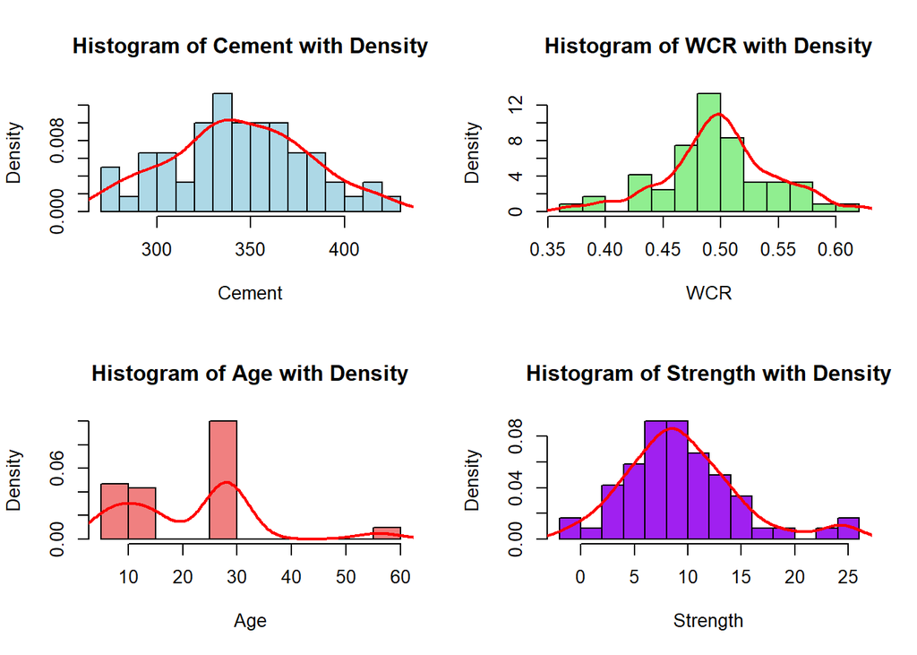

```r
# Part a): Data Preparation
# [a-1] Histograms with overlaid marginal density distributions
par(mfrow = c(2, 2))

# cement
hist(concrete$cement, main = "Histogram of Cement with Density",
     xlab = "Cement", col = "lightblue", probability = TRUE, breaks = 15)
lines(density(concrete$cement), col = "red", lwd = 2)

# wcr
hist(concrete$wcr, main = "Histogram of WCR with Density",
     xlab = "WCR", col = "lightgreen", probability = TRUE, breaks = 15)
lines(density(concrete$wcr), col = "red", lwd = 2)

# age
hist(concrete$age, main = "Histogram of Age with Density",
     xlab = "Age", col = "lightcoral", probability = TRUE, breaks = 15)
lines(density(concrete$age), col = "red", lwd = 2)

# strength
hist(concrete$strength, main = "Histogram of Strength with Density",
     xlab = "Strength", col = "purple", probability = TRUE, breaks = 15)
lines(density(concrete$strength), col = "red", lwd = 2)
```

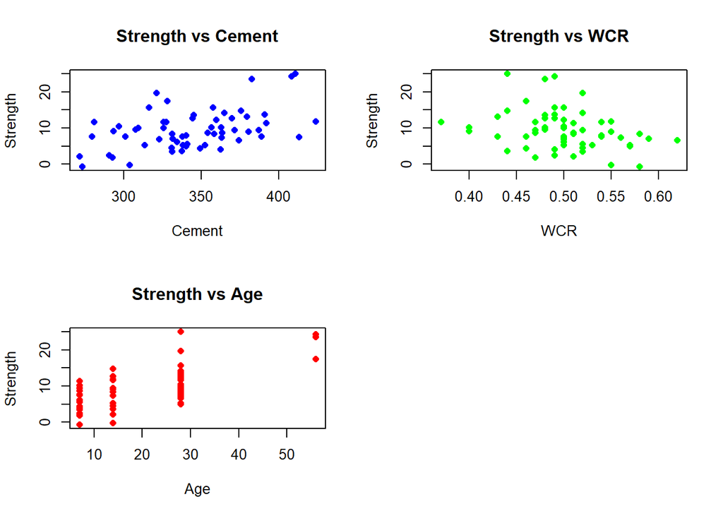

```r
par(mfrow = c(1, 1))

# [a-2] Scatter Plots of Strength against each Predictor
par(mfrow = c(2, 2))

# Strength vs Cement
plot(concrete$cement, concrete$strength, main = "Strength vs Cement",
     xlab = "Cement", ylab = "Strength", pch = 16, col = "blue")


# Strength vs WCR
plot(concrete$wcr, concrete$strength, main = "Strength vs WCR",
     xlab = "WCR", ylab = "Strength", pch = 16, col = "green")

# Strength vs Age
plot(concrete$age, concrete$strength, main = "Strength vs Age",
     xlab = "Age", ylab = "Strength", pch = 16, col = "red")

par(mfrow = c(1, 1))
```

#### **Commenting on the Trend and Need for Variable Transformation**

The marginal plots are not skewed. No clear need for variable transformations

The scatter plot for strength vs age indicates has distinct values (7, 14, 28, 56) which suggests a discrete or categorical nature rather than continuous. The marginal plots also show spikes at these specific ages rather than a smooth distribution.

Therefore, age may be as a **categorical variable** (factor) in regression to account for its discrete levels. Including *interaction terms* (e.g., cement:age, wcr:age) in such a regression model may be also necessary.

```r
# Part b): Multicollinearity among predictors

# (i) Pearson correlation coefficients
cor(concrete, method = "pearson")
```

```
##              cement         wcr         age   strength
## cement   1.00000000  0.08414330  0.07698239  0.4657863
## wcr      0.08414330  1.00000000 -0.02466868 -0.3063764
## age      0.07698239 -0.02466868  1.00000000  0.6345642
## strength 0.46578632 -0.30637643  0.63456425  1.0000000
```

```r
# Compute the correlation matrix - Same!
cor_matrix <- cor(concrete[, c("cement","wcr","age","strength")])
print(cor_matrix)
```

```
##              cement         wcr         age   strength
## cement   1.00000000  0.08414330  0.07698239  0.4657863
## wcr      0.08414330  1.00000000 -0.02466868 -0.3063764
## age      0.07698239 -0.02466868  1.00000000  0.6345642
## strength 0.46578632 -0.30637643  0.63456425  1.0000000
```

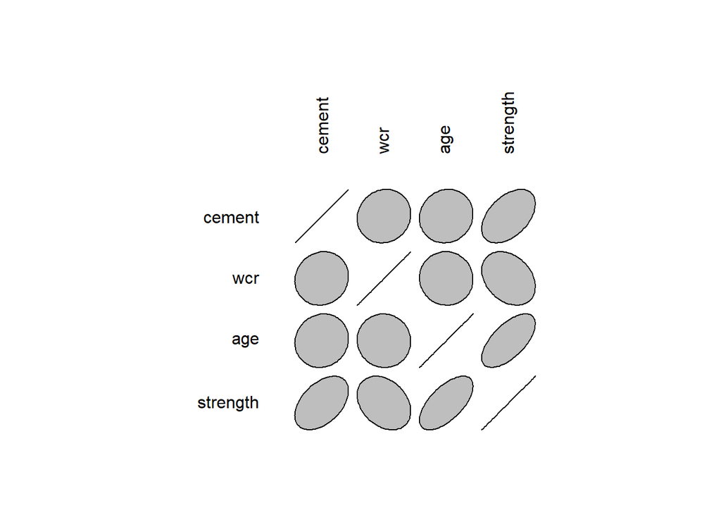

```r
# (ii) An ellipse plot to visualise collinearity
pacman::p_load(ellipse)
plotcorr(cor(concrete))
```

```r
# (iii) Variance Inflation Factors (VIFs)
pacman::p_load(car)
conc_model <- lm(strength ~ cement + wcr + age, data = concrete)
vif(conc_model)
```

```
##   cement      wcr      age
## 1.013514 1.008121 1.006951
```

```r
# Part-C-1 Model
conc_model <- lm(strength ~ cement + wcr + age, data = concrete)
summary(conc_model)
```

```
##
## Call:
## lm(formula = strength ~ cement + wcr + age, data = concrete)
##
## Residuals:
##    Min     1Q Median     3Q    Max
## -5.718 -2.303 -0.037  1.123 10.743
##
## Coefficients:
##              Estimate Std. Error t value Pr(>|t|)
## (Intercept)  -0.40525    5.54484  -0.073    0.942
## cement        0.06657    0.01122   5.935 1.94e-07 ***
## wcr         -37.44811    8.55637  -4.377 5.31e-05 ***
## age           0.26614    0.03383   7.868 1.27e-10 ***
## ---
## Signif. codes:  0 '***' 0.001 '**' 0.01 '*' 0.05 '.' 0.1 ' ' 1
##
## Residual standard error: 3.11 on 56 degrees of freedom
## Multiple R-squared:  0.6852, Adjusted R-squared:  0.6684
## F-statistic: 40.63 on 3 and 56 DF,  p-value: 4.441e-14
```

```r
confint(conc_model)
```

```
##                    2.5 %       97.5 %
## (Intercept) -11.51290192  10.70239966
## cement        0.04410025   0.08904318
## wcr         -54.58857939 -20.30764934
## age           0.19838020   0.33389978
```

```r
# Part C-2: Comment on the Model output
# -Regression coefficients
# -Model significance
# -Adequacy of fit, and
# -Appropriateness of fit

## Residual analysis
resplot(conc_model)
```

[output not shown]

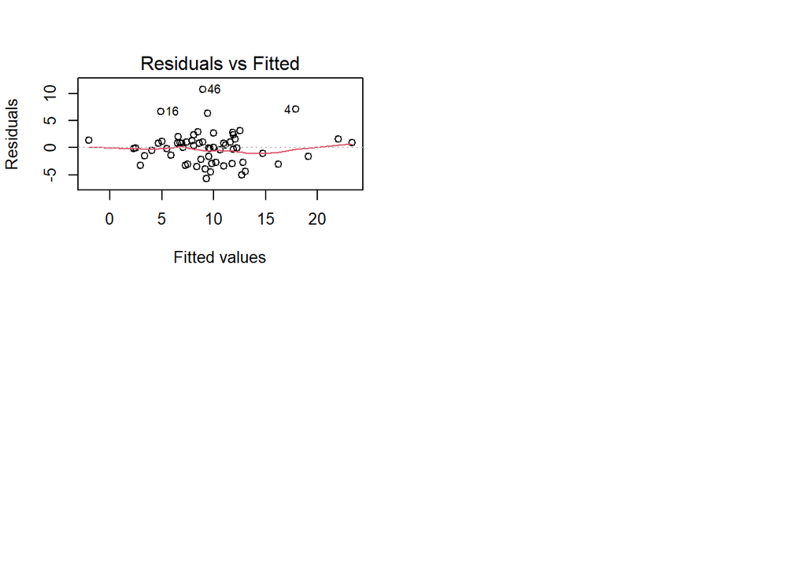

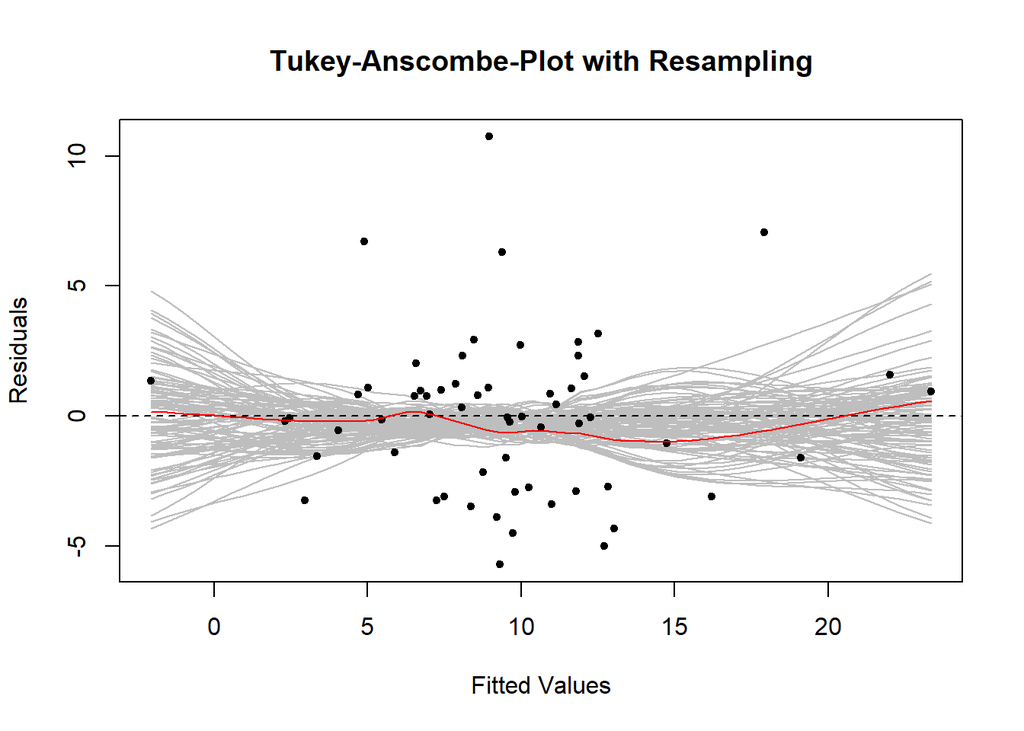

```r
plot(conc_model, which=1)
resplot(conc_model, plots = 1)
```

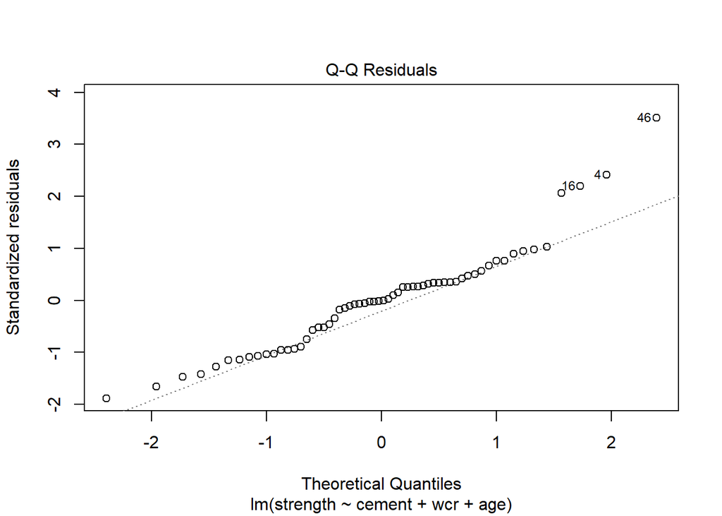

```r
plot(conc_model, which = 2)
```

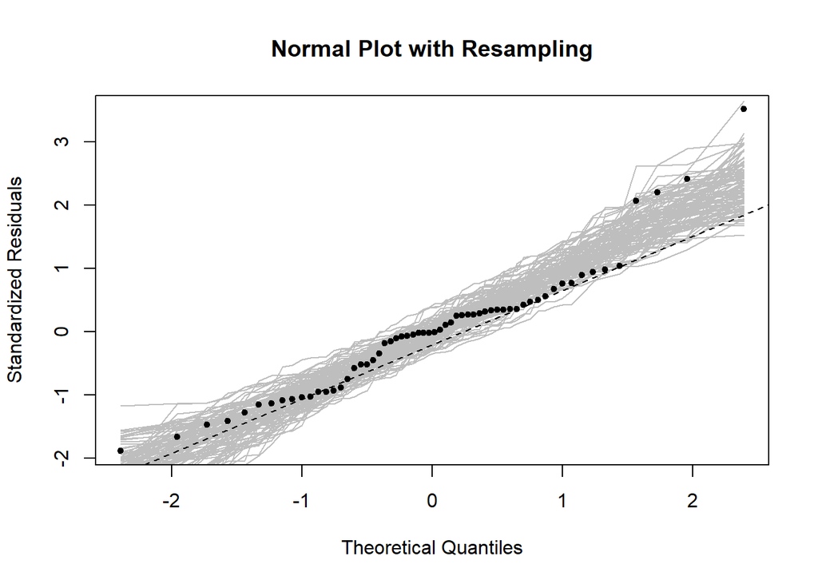

```r
resplot(conc_model, plots = 2)
```

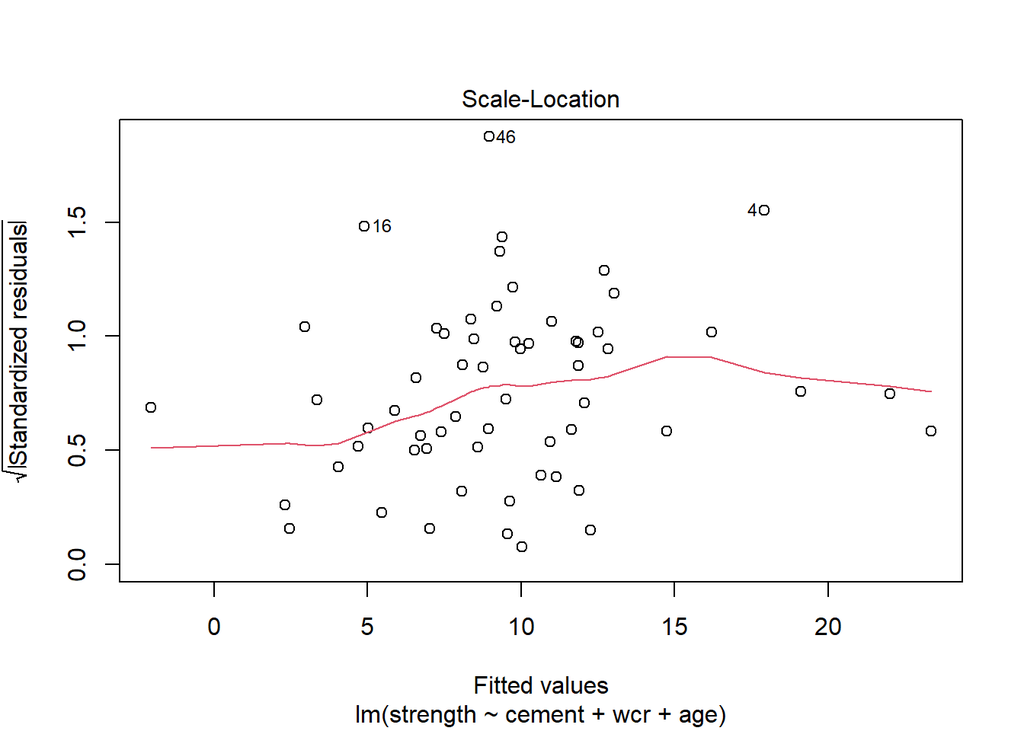

```r
## Scale-location plot
plot(conc_model, which = 3)
```

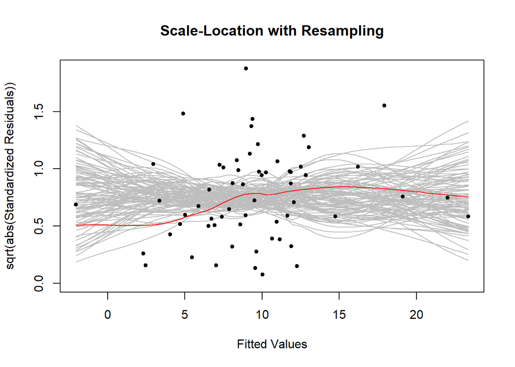

```r
resplot(conc_model, plots = 3)
```

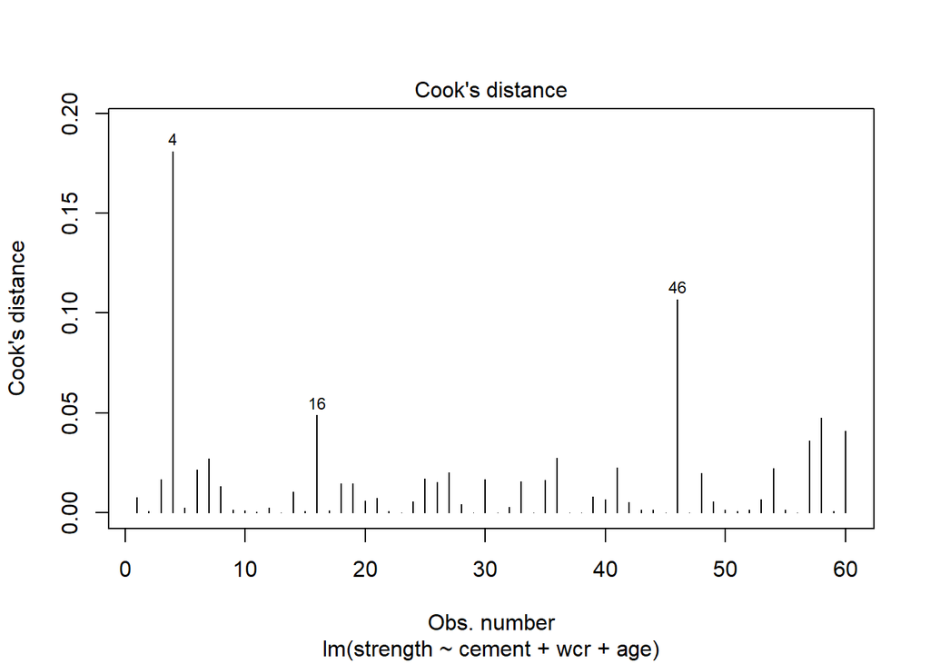

```r
## Cook's Distance plot
plot(conc_model, which = 4)
```

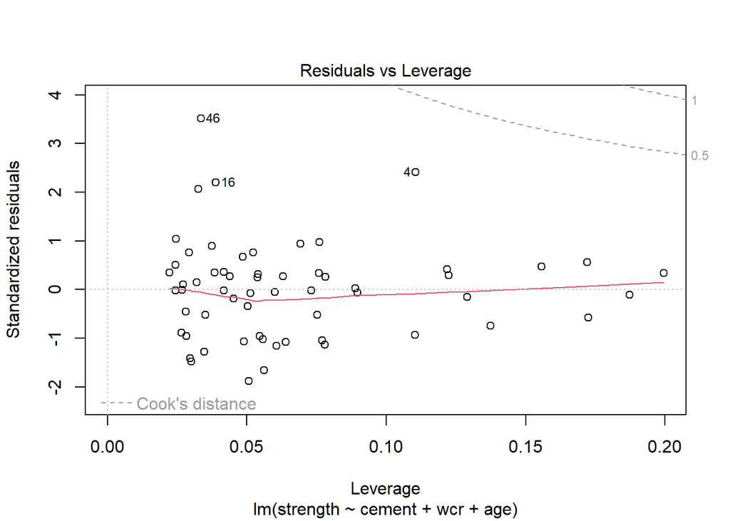

```r
plot(conc_model, which = 5)
```

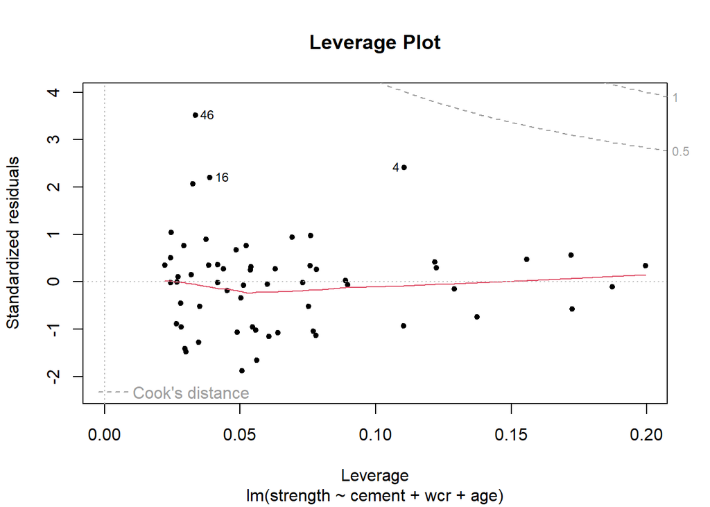

```r
resplot(conc_model, plots = 4)
```

```r
# Autocorrelation using the Durbin-Watson test
pacman::p_load(lmtest)
dwtest(conc_model)
```

```
##
##  Durbin-Watson test
##
## data:  conc_model
## DW = 1.8426, p-value = 0.2733
## alternative hypothesis: true autocorrelation is greater than 0
```

Assumptions not violated, No Autocorrelation.

```r
# Part d): Variable Selection
# Backward Elimination with AIC
conc.back <- stats::step(conc_model, direction="backward")
```

```
## Start:  AIC=140.02
## strength ~ cement + wcr + age
##
##          Df Sum of Sq     RSS    AIC
## <none>                 541.67 140.02
## - wcr     1    185.28  726.95 155.67
## - cement  1    340.67  882.34 167.29
## - age     1    598.81 1140.49 182.69
```

```r
summary(conc.back)
```

```
##
## Call:
## lm(formula = strength ~ cement + wcr + age, data = concrete)
##
## Residuals:
##    Min     1Q Median     3Q    Max
## -5.718 -2.303 -0.037  1.123 10.743
##
## Coefficients:
##              Estimate Std. Error t value Pr(>|t|)
## (Intercept)  -0.40525    5.54484  -0.073    0.942
## cement        0.06657    0.01122   5.935 1.94e-07 ***
## wcr         -37.44811    8.55637  -4.377 5.31e-05 ***
## age           0.26614    0.03383   7.868 1.27e-10 ***
## ---
## Signif. codes:  0 '***' 0.001 '**' 0.01 '*' 0.05 '.' 0.1 ' ' 1
##
## Residual standard error: 3.11 on 56 degrees of freedom
## Multiple R-squared:  0.6852, Adjusted R-squared:  0.6684
## F-statistic: 40.63 on 3 and 56 DF,  p-value: 4.441e-14
```

```r
resplot(conc.back)
```

[output not shown]

```r
# Forward Selection with AIC
conc_null <- lm(strength ~ 1, data = concrete) # Intercept-only model
sc <- list(lower=conc_null, upper=conc_model)
conc.forw <- stats::step(conc_null, scope=sc, direction="forward", k=2)
```

```
## Start:  AIC=203.37
## strength ~ 1
##
##          Df Sum of Sq    RSS    AIC
## + age     1    692.91 1027.9 174.45
## + cement  1    373.33 1347.4 190.70
## + wcr     1    161.52 1559.2 199.46
## <none>                1720.8 203.37
##
## Step:  AIC=174.45
## strength ~ age
##
##          Df Sum of Sq     RSS    AIC
## + cement  1    300.92  726.95 155.67
## + wcr     1    145.53  882.34 167.29
## <none>                1027.87 174.45
##
## Step:  AIC=155.67
## strength ~ age + cement
##
##        Df Sum of Sq    RSS    AIC
## + wcr   1    185.28 541.67 140.02
## <none>              726.95 155.67
##
## Step:  AIC=140.02
## strength ~ age + cement + wcr
```

```r
summary(conc.forw)
```

```
##
## Call:
## lm(formula = strength ~ age + cement + wcr, data = concrete)
##
## Residuals:
##    Min     1Q Median     3Q    Max
## -5.718 -2.303 -0.037  1.123 10.743
##
## Coefficients:
##              Estimate Std. Error t value Pr(>|t|)
## (Intercept)  -0.40525    5.54484  -0.073    0.942
## age           0.26614    0.03383   7.868 1.27e-10 ***
## cement        0.06657    0.01122   5.935 1.94e-07 ***
## wcr         -37.44811    8.55637  -4.377 5.31e-05 ***
## ---
## Signif. codes:  0 '***' 0.001 '**' 0.01 '*' 0.05 '.' 0.1 ' ' 1
##
## Residual standard error: 3.11 on 56 degrees of freedom
## Multiple R-squared:  0.6852, Adjusted R-squared:  0.6684
## F-statistic: 40.63 on 3 and 56 DF,  p-value: 4.441e-14
```

```r
resplot(conc.forw)
```

[output not shown]

```r
# AIC Stepwise Model Search: Both Directions Approach
# starting with the null model
conc.b1 <- stats::step(conc_null, scope = sc, direction = "both")
```

```
## Start:  AIC=203.37
## strength ~ 1
##
##          Df Sum of Sq    RSS    AIC
## + age     1    692.91 1027.9 174.45
## + cement  1    373.33 1347.4 190.70
## + wcr     1    161.52 1559.2 199.46
## <none>                1720.8 203.37
##
## Step:  AIC=174.45
## strength ~ age
##
##          Df Sum of Sq     RSS    AIC
## + cement  1    300.92  726.95 155.67
## + wcr     1    145.53  882.34 167.29
## <none>                1027.87 174.45
## - age     1    692.91 1720.78 203.37
##
## Step:  AIC=155.67
## strength ~ age + cement
##
##          Df Sum of Sq     RSS    AIC
## + wcr     1    185.28  541.67 140.02
## <none>                 726.95 155.67
## - cement  1    300.92 1027.87 174.45
## - age     1    620.49 1347.44 190.70
##
## Step:  AIC=140.02
## strength ~ age + cement + wcr
##
##          Df Sum of Sq     RSS    AIC
## <none>                 541.67 140.02
## - wcr     1    185.28  726.95 155.67
## - cement  1    340.67  882.34 167.29
## - age     1    598.81 1140.49 182.69
```

```r
summary(conc.b1)
```

```
##
## Call:
## lm(formula = strength ~ age + cement + wcr, data = concrete)
##
## Residuals:
##    Min     1Q Median     3Q    Max
## -5.718 -2.303 -0.037  1.123 10.743
##
## Coefficients:
##              Estimate Std. Error t value Pr(>|t|)
## (Intercept)  -0.40525    5.54484  -0.073    0.942
## age           0.26614    0.03383   7.868 1.27e-10 ***
## cement        0.06657    0.01122   5.935 1.94e-07 ***
## wcr         -37.44811    8.55637  -4.377 5.31e-05 ***
## ---
## Signif. codes:  0 '***' 0.001 '**' 0.01 '*' 0.05 '.' 0.1 ' ' 1
##
## Residual standard error: 3.11 on 56 degrees of freedom
## Multiple R-squared:  0.6852, Adjusted R-squared:  0.6684
## F-statistic: 40.63 on 3 and 56 DF,  p-value: 4.441e-14
```

```r
resplot(conc.b1)

# starting with the full model
conc.b2 <- stats::step(conc_model, scope = sc, direction = "both")
```

[output not shown]

```
## Start:  AIC=140.02
## strength ~ cement + wcr + age
##
##          Df Sum of Sq     RSS    AIC
## <none>                 541.67 140.02
## - wcr     1    185.28  726.95 155.67
## - cement  1    340.67  882.34 167.29
## - age     1    598.81 1140.49 182.69
```

```r
summary(conc.b2)
```

```
##
## Call:
## lm(formula = strength ~ cement + wcr + age, data = concrete)
##
## Residuals:
##    Min     1Q Median     3Q    Max
## -5.718 -2.303 -0.037  1.123 10.743
##
## Coefficients:
##              Estimate Std. Error t value Pr(>|t|)
## (Intercept)  -0.40525    5.54484  -0.073    0.942
## cement        0.06657    0.01122   5.935 1.94e-07 ***
## wcr         -37.44811    8.55637  -4.377 5.31e-05 ***
## age           0.26614    0.03383   7.868 1.27e-10 ***
## ---
## Signif. codes:  0 '***' 0.001 '**' 0.01 '*' 0.05 '.' 0.1 ' ' 1
##
## Residual standard error: 3.11 on 56 degrees of freedom
## Multiple R-squared:  0.6852, Adjusted R-squared:  0.6684
## F-statistic: 40.63 on 3 and 56 DF,  p-value: 4.441e-14
```

```r
resplot(conc.b2)
```

[output not shown]

```r
# starting with a model somewhere in the middle
conc_mid <- lm(strength ~  wcr + age, data = concrete)
conc.b3 <- stats::step(conc_mid, scope = sc, direction = "both")
```

```
## Start:  AIC=167.29
## strength ~ wcr + age
##
##          Df Sum of Sq     RSS    AIC
## + cement  1    340.67  541.67 140.02
## <none>                 882.34 167.29
## - wcr     1    145.53 1027.87 174.45
## - age     1    676.91 1559.25 199.46
##
## Step:  AIC=140.02
## strength ~ wcr + age + cement
##
##          Df Sum of Sq     RSS    AIC
## <none>                 541.67 140.02
## - wcr     1    185.28  726.95 155.67
## - cement  1    340.67  882.34 167.29
## - age     1    598.81 1140.49 182.69
```

```r
summary(conc.b3)
```

```
##
## Call:
## lm(formula = strength ~ wcr + age + cement, data = concrete)
##
## Residuals:
##    Min     1Q Median     3Q    Max
## -5.718 -2.303 -0.037  1.123 10.743
##
## Coefficients:
##              Estimate Std. Error t value Pr(>|t|)
## (Intercept)  -0.40525    5.54484  -0.073    0.942
## wcr         -37.44811    8.55637  -4.377 5.31e-05 ***
## age           0.26614    0.03383   7.868 1.27e-10 ***
## cement        0.06657    0.01122   5.935 1.94e-07 ***
## ---
## Signif. codes:  0 '***' 0.001 '**' 0.01 '*' 0.05 '.' 0.1 ' ' 1
##
## Residual standard error: 3.11 on 56 degrees of freedom
## Multiple R-squared:  0.6852, Adjusted R-squared:  0.6684
## F-statistic: 40.63 on 3 and 56 DF,  p-value: 4.441e-14
```

```r
resplot(conc.b3)
```

[output not shown]

```r
# AIC is used when the principal aim is the prediction
```

All predictors are kept in all 6 models. There are no major improvements in residual plots for all the models. Also, no noticeable changes on predictor significance or model fit.

```r
# Part e) 5-fold cross validation
# Full Model is (strength ~ cement + wcr + age)
# Reduced Model is (strength ~ cement + age); wcr is dropped to see effect on prediction performance

set.seed(123) # Set seed for reproducibility

n <- nrow(concrete) # Number of observations
k <- 5 # Number of folds
sb <- round(seq(0, n, length = (k + 1)))  # Fold boundaries

# Initialize vectors to store MSPE for each model
mspe_full <- numeric(k)
mspe_reduced <- numeric(k)

# 5-fold cross-validation for full model (strength ~ cement + wcr + age)
for (i in 1:k) {
  test <- (sb[k + 1 - i] + 1):sb[k + 2 - i]
  train <- (1:n)[-test]
  fit_full <- lm(strength ~ cement + wcr + age, data = concrete[train, ])
  pred_full <- predict(fit_full, newdata = concrete[test, ])
  mspe_full[i] <- mean((concrete$strength[test] - pred_full)^2, na.rm = TRUE)
}

# 5-fold cross-validation for reduced model (strength ~ cement + age)
for (i in 1:k) {
  test <- (sb[k + 1 - i] + 1):sb[k + 2 - i]  # Same fold split comparability
  train <- (1:n)[-test]
  fit_reduced <- lm(strength ~ cement + age, data = concrete[train, ])
  pred_reduced <- predict(fit_reduced, newdata = concrete[test, ])
  mspe_reduced[i] <- mean((concrete$strength[test] - pred_reduced)^2, na.rm = TRUE)
}

# Calculating overall MSPE for each model
mspe_full_mean <- mean(mspe_full, na.rm = TRUE)
mspe_reduced_mean <- mean(mspe_reduced, na.rm = TRUE)

# Report results
cat("MSPE per fold for Full Model:", mspe_full, "\n")
```

```
## MSPE per fold for Full Model: 10.68408 15.07415 8.694391 6.984834 11.73812
```

```r
cat("MSPE per fold for Reduced Model:", mspe_reduced, "\n")
```

```
## MSPE per fold for Reduced Model: 15.09433 13.59734 7.99105 9.425239 20.52089
```

```r
cat("MSPE for Full Model:", mspe_full_mean, "\n")
```

```
## MSPE for Full Model: 10.63511
```

```r
cat("MSPE for Reduced Model:", mspe_reduced_mean, "\n")
```

```
## MSPE for Reduced Model: 13.32577
```

```r
# Relative increase in MSPE
relative_increase <- ((mspe_reduced_mean - mspe_full_mean) / mspe_full_mean) * 100
cat("Relative increase in MSPE (%):", relative_increase, "\n")
```

```
## Relative increase in MSPE (%): 25.29973
```

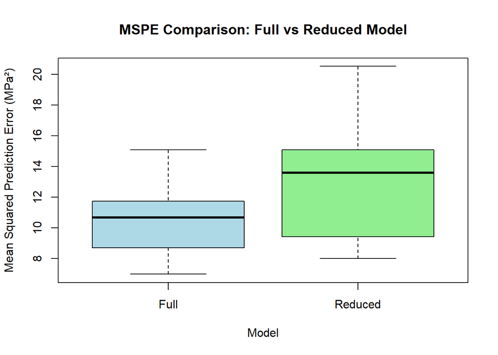

```r
# Box plots using MSPEs
# Combining MSPEs into a data frame for plotting
mspe_data <- data.frame(
  MSPE = c(mspe_full, mspe_reduced),
  Model = factor(rep(c("Full", "Reduced"), each = k))
)
# Generating box plots
boxplot(MSPE ~ Model, data = mspe_data,
        main = "MSPE Comparison: Full vs Reduced Model",
        ylab = "Mean Squared Prediction Error (MPa²)",
        col = c("lightblue", "lightgreen"),
        border = "black")
```

From the cross-validation exercise, The MSPE for the reduced is substantially higher (25.29973%) than the full model. Therefore, the variable wcr adds predictive power and the full model is preferable for prediction purposes.

```r
# Part f): Prediction
conc.str <- data.frame(cement=350, wcr=0.5, age=28)
# predict(conc_model, newdata = conc.str, interval = "conf")
predict(conc_model, newdata = conc.str, interval = "pred")
```

```
##        fit      lwr      upr
## 1 11.62271 5.324389 17.92103
```